# Complete between subject ANCOVA Tutorial

Mo’men Mohamed

April 4, 2019

For Any advice of suggestion plz feel free to Contact me : vet.m.mohamed@gmail.com

Find the Complete Tutorial and data sets [here](http://statstools.com/learn/advanced-statistics/)

**Note**: running the test although vilating some normality here since this analysis for tutorial only

loading the libraries

```r
library(knitr)
library(tidyverse)
library(car)
library(effects)
library(multcomp)
library(MOTE)
```

loading the data

```r
data<-read.csv("./data sets/bn ancova.csv")

head(data)
```

```
##   ï..subjno attdrug phyheal menheal psydrug    emplmnt      religion
## 1         1       8       5       8       0 UNEMPLOYED    PROTESTANT
## 2         2       7       4       6       0   EMPLOYED    PROTESTANT
## 3         3       8       3       4       2   EMPLOYED      CATHOLIC
## 4         4       9       2       2       3 UNEMPLOYED NONE OR OTHER
## 5         5       7       3       6      15 UNEMPLOYED        JEWISH
## 6         6       8       5       5       3   EMPLOYED      CATHOLIC
```

selecting the variables

```r
data<-data[,c("ï..subjno","attdrug","phyheal","emplmnt","religion")]

head(data)
```

```
##   ï..subjno attdrug phyheal    emplmnt      religion
## 1         1       8       5 UNEMPLOYED    PROTESTANT
## 2         2       7       4   EMPLOYED    PROTESTANT
## 3         3       8       3   EMPLOYED      CATHOLIC
## 4         4       9       2 UNEMPLOYED NONE OR OTHER
## 5         5       7       3 UNEMPLOYED        JEWISH
## 6         6       8       5   EMPLOYED      CATHOLIC
```

the assumptions includes : Accuracy missing outliers aditivity Normality Linearity Homogeniety + homoscdasticity

accuracy

```r
summary(data) #we have a problem in levels of religion
```

```
##    ï..subjno        attdrug          phyheal             emplmnt
##  Min.   :  1.0   Min.   : 5.000   Min.   : 2.000   EMPLOYED  :246
##  1st Qu.:137.0   1st Qu.: 7.000   1st Qu.: 3.000   UNEMPLOYED:219
##  Median :314.0   Median : 8.000   Median : 5.000
##  Mean   :317.4   Mean   : 7.686   Mean   : 4.972
##  3rd Qu.:483.0   3rd Qu.: 9.000   3rd Qu.: 6.000
##  Max.   :758.0   Max.   :10.000   Max.   :15.000
##           religion
##               :  3
##  CATHOLIC     :119
##  JEWISH       : 92
##  NONE OR OTHER: 76
##  PROTESTANT   :175
##
```

```r
data<-data%>%mutate(religion=factor(religion,levels = c("CATHOLIC",
                                                        "JEWISH",
                                                        "NONE OR OTHER",
                                                        "PROTESTANT"),labels = c("CATHOLIC",
                                                                                 "JEWISH",
                                                                                 "NONE",
                                                                                 "PROTESTANT")))
summary(data)
```

```
##    ï..subjno        attdrug          phyheal             emplmnt
##  Min.   :  1.0   Min.   : 5.000   Min.   : 2.000   EMPLOYED  :246
##  1st Qu.:137.0   1st Qu.: 7.000   1st Qu.: 3.000   UNEMPLOYED:219
##  Median :314.0   Median : 8.000   Median : 5.000
##  Mean   :317.4   Mean   : 7.686   Mean   : 4.972
##  3rd Qu.:483.0   3rd Qu.: 9.000   3rd Qu.: 6.000
##  Max.   :758.0   Max.   :10.000   Max.   :15.000
##        religion
##  CATHOLIC  :119
##  JEWISH    : 92
##  NONE      : 76
##  PROTESTANT:175
##  NA's      :  3
##
```

missing –> we have only 3 cases in religion

outliers – > mahalanobis of CV and DV

```r
mah<-mahalanobis(x = data[,c("attdrug","phyheal")],center = colMeans(data[,c("attdrug","phyheal")]),cov = cov(data[,c("attdrug","phyheal")]))
cut<-qchisq(p = .99,df = 2)

data<-data[which(mah<cut),]
```

sditivity

```r
(cor(data$attdrug,data$phyheal))
```

```
## [1] 0.1494295
```

normality

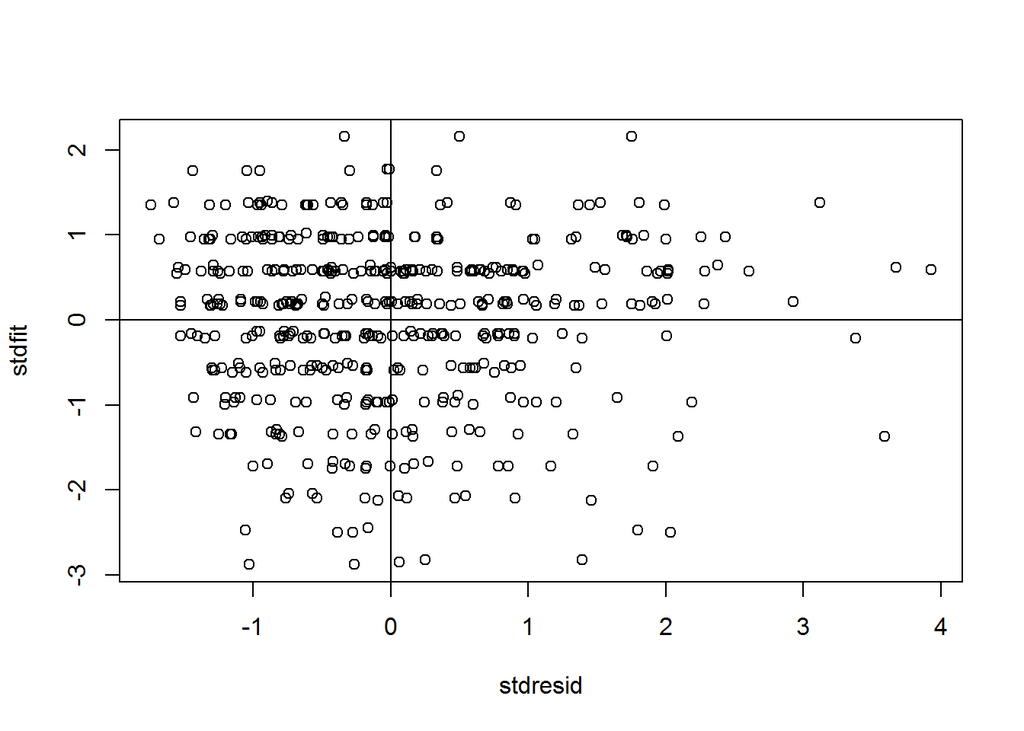

```r
chi<-rchisq(nrow(data),df = 7)

fake<-lm(chi~data$attdrug+data$phyheal)

stdresid<-rstudent(fake)
stdfit<-scale(fitted(fake))

plot(stdresid,stdfit)%>%abline(v = 0)%>%abline(h= 0)
```

we might face a problem in homogeniety but the homoscdacity is great

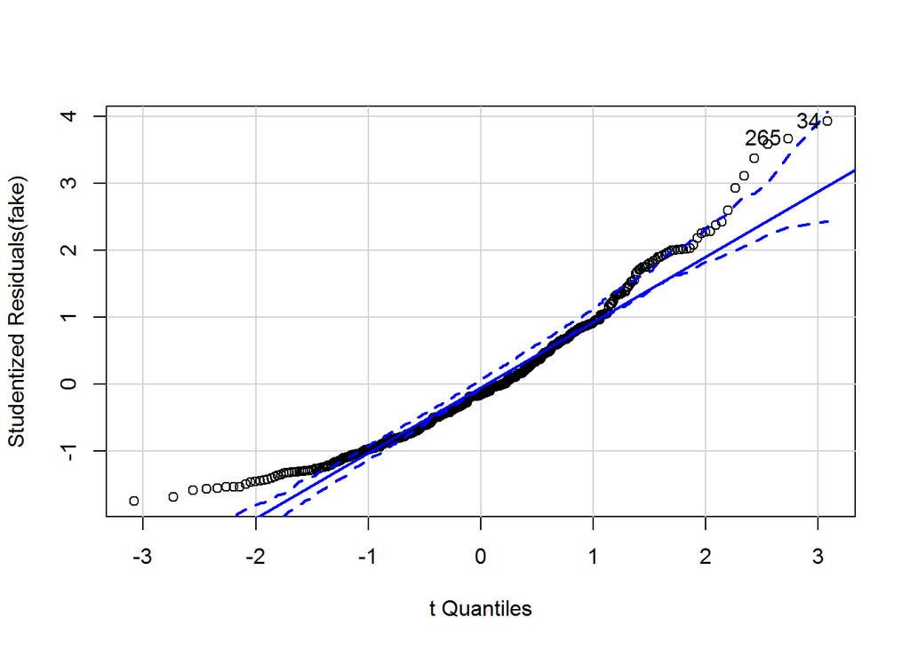

```
## [1]  34 265
```

```r
qqPlot(fake)  #the linearity is not so bad
```